# MA_Hw_04_03

## Packages

```r
suppressMessages(library(tidyverse))
suppressMessages(library(rstan))
suppressMessages(library(rethinking))
suppressMessages(library(gridExtra))
suppressMessages(library(MASS))
```

## Import Data

```r
data("eagles")
eagles
```

|  | y | n | P | A | V |
| --- | --- | --- | --- | --- | --- |
| 1 | 17 | 24 | L | A | L |
| 2 | 29 | 29 | L | A | S |
| 3 | 17 | 27 | L | I | L |
| 4 | 20 | 20 | L | I | S |
| 5 | 1 | 12 | S | A | L |
| 6 | 15 | 16 | S | A | S |
| 7 | 0 | 28 | S | I | L |
| 8 | 1 | 4 | S | I | S |

## Data-processing

```r
eagles$P <- ifelse(eagles$P == "L", 1,0) # Priate 1:Large, 0:Small
eagles$A <- ifelse(eagles$A == "A", 1,0) # Eagle 1:Adult, 0:Immature
eagles$V <- ifelse(eagles$V == "L", 1,0) # Priate 1:Large, 0:Small
eagles
```

|  | y | n | P | A | V |
| --- | --- | --- | --- | --- | --- |
| 1 | 17 | 24 | 1 | 1 | 1 |
| 2 | 29 | 29 | 1 | 1 | 0 |
| 3 | 17 | 27 | 1 | 0 | 1 |
| 4 | 20 | 20 | 1 | 0 | 0 |
| 5 | 1 | 12 | 0 | 1 | 1 |
| 6 | 15 | 16 | 0 | 1 | 0 |
| 7 | 0 | 28 | 0 | 0 | 1 |
| 8 | 1 | 4 | 0 | 0 | 0 |

## Part A

### model

```r
q3_a_m1 = "
data{
  int N;
  int y[N];
  int n[N];
  int P[N]; //big pirate
  int A[N]; //big eagles
  int V[N]; //adult priate
}

parameters{
  real alpha;
  real beta_p;
  real beta_v;
  real beta_a;
}

transformed parameters{
  real p[N];
  for(i in 1:N){
    p[i] = inv_logit(alpha + beta_p*P[i] + beta_v*V[i] + beta_a*A[i]);
  }
}

model{
  y ~ binomial(n, p);
  alpha ~ normal(0,10);
  beta_p ~ normal(0,5);
  beta_v ~ normal(0,5);
  beta_a ~ normal(0,5);
}

generated quantities{
  vector[N] log_lik;
  int pred_y[N];
  real pred_p[N];

  for(i in 1:N){
    pred_y[i] = binomial_rng(n[i], p[i]);
    log_lik[i] = binomial_lpmf(pred_y[i] | n[i], p[i]);
    pred_p[i] = inv_logit(alpha + beta_p*P[i] + beta_v*V[i] + beta_a*A[i]);
  }
}
"

q3_a_data = list(
                N = nrow(eagles),
                y = eagles$y,
                n = eagles$n,
                P = eagles$P,
                A = eagles$A,
                V = eagles$V)

q3_a_fit = stan(
              model_code = q3_a_m1,
              data = q3_a_data,
              iter = 5000,
              chains = 2)
```

```
Tail Effective Samples Size (ESS) is too low, indicating posterior variances and tail quantiles may be unreliable.
Running the chains for more iterations may help. See
http://mc-stan.org/misc/warnings.html#tail-ess
```

## Part B

### Analysis

1. The predicted probability of success, which means the probability of successfully catch the pirate, and its 89% interval contains the highest 89% posterior density of probability of success in the interval, which can be regarded as the most possible interval the predicted probability of success would be. We can also consider it to be that if we do 100 times sampling, we would get the value of probability of success bounded in that interval 89 times.
2. Just like above, the predicted success count and its 89% interval. We can also consider it to be that if we do 100 times sampling, we would get the value of success count bounded in that interval 89 times.
3. One tells the probability of success, and another tells the amount

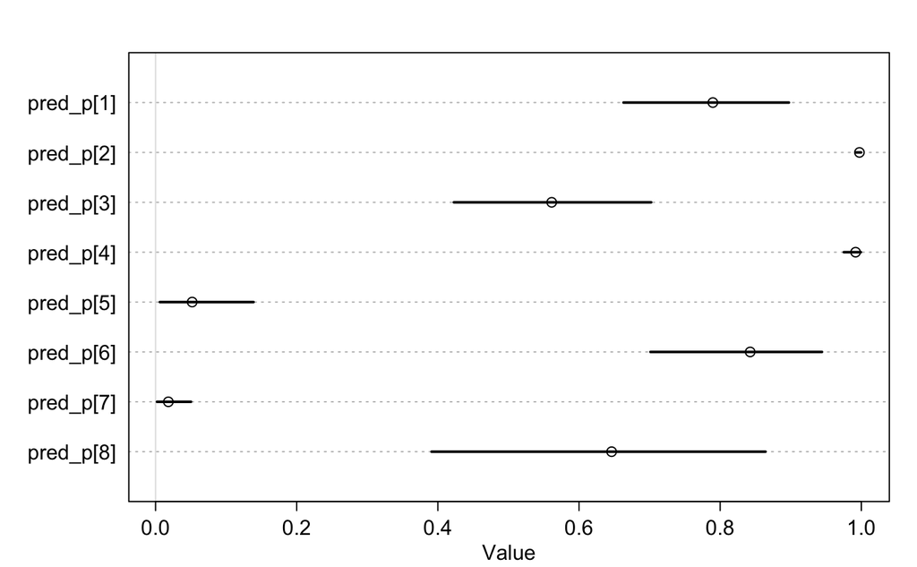

```r
q2_b_result1 = as.data.frame(q3_a_fit)

rows_pred_p = q2_b_result1 %>% dplyr::select(contains("pred_p"))
rows_pred_y = q2_b_result1 %>% dplyr::select(contains("pred_y"))

plot( precis( as.data.frame(rows_pred_p), prob=0.89, depth=2))
```

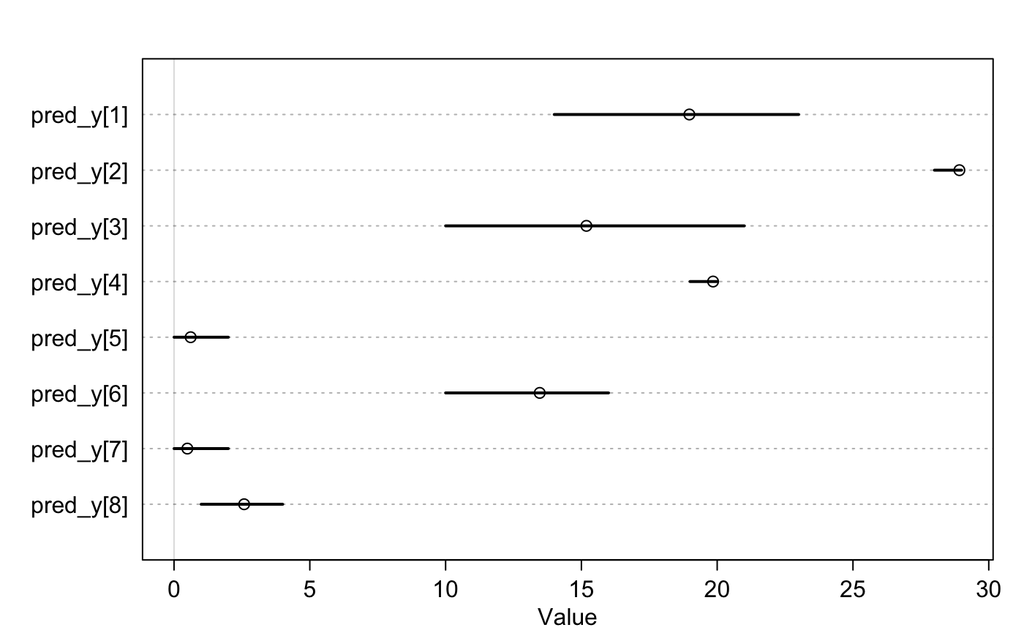

```r
plot( precis( as.data.frame(rows_pred_y), prob=0.89, depth=2))
```

## Part C

### Add Interaction

Adding Interaction of P and V

```r
eagles_interaction = eagles %>% mutate(PV = P*V)
eagles_interaction
```

| y | n | P | A | V | PV |
| --- | --- | --- | --- | --- | --- |
| 17 | 24 | 1 | 1 | 1 | 1 |
| 29 | 29 | 1 | 1 | 0 | 0 |
| 17 | 27 | 1 | 0 | 1 | 1 |
| 20 | 20 | 1 | 0 | 0 | 0 |
| 1 | 12 | 0 | 1 | 1 | 0 |
| 15 | 16 | 0 | 1 | 0 | 0 |
| 0 | 28 | 0 | 0 | 1 | 0 |
| 1 | 4 | 0 | 0 | 0 | 0 |

### Model

This is the model with interaction of P and V

```r
q3_c_m1 = "
data{
  int N;
  int y[N];
  int n[N];
  int P[N]; //big pirate
  int A[N]; //big eagles
  int V[N]; //adult priate
  int PV[N];
}

parameters{
  real alpha;
  real beta_p;
  real beta_v;
  real beta_a;
  real beta_pv;
}

transformed parameters{
  real p[N];
  for(i in 1:N){
    p[i] = inv_logit(alpha + beta_p*P[i] + beta_v*V[i] + beta_a*A[i] + beta_pv*PV[i]);
  }
}

model{
  y ~ binomial(n, p);
  alpha ~ normal(0,10);
  beta_p ~ normal(0,5);
  beta_v ~ normal(0,5);
  beta_a ~ normal(0,5);
  beta_pv ~ normal(0,5);
}

generated quantities{
  vector[N] log_lik;
  int pred_y[N];
  real pred_p[N];

  for(i in 1:N){
    pred_y[i] = binomial_rng(n[i], p[i]);
    log_lik[i] = binomial_lpmf(pred_y[i] | n[i], p[i]);
    pred_p[i] = alpha + beta_p*P[i] + beta_v*V[i] + beta_a*A[i] + beta_pv*PV[i];
  }
}
"

q3_c_data = list(
                N = nrow(eagles_interaction),
                y = eagles_interaction$y,
                n = eagles_interaction$n,
                P = eagles_interaction$P,
                A = eagles_interaction$A,
                V = eagles_interaction$V,
                PV = eagles_interaction$PV)

q3_c_fit = stan(
              model_code = q3_c_m1,
              data = q3_c_data,
              iter = 4000,
              chains = 2)
```

```
Tail Effective Samples Size (ESS) is too low, indicating posterior variances and tail quantiles may be unreliable.
Running the chains for more iterations may help. See
http://mc-stan.org/misc/warnings.html#tail-ess
```

### WAIC

```r
compare(q3_a_fit, q3_c_fit)
```

|  | WAIC | SE | dWAIC | dSE | pWAIC | weight |
| --- | --- | --- | --- | --- | --- | --- |
| q3_a_fit | 24.8 | 4.00 | 0.0 | NA | 4.0 | 0.54 |
| q3_c_fit | 25.1 | 3.96 | 0.3 | 0.38 | 4.1 | 0.46 |